# *Train* and *Test* Partitions

Alan T. Arnholt

Last knit on February 18, 2018 at 08:46:58 PM

# 1 Partitions

- Using the `sample()` function (method 1):

```r
> library(mdsr)
> HELP <- na.omit(HELPrct)
> set.seed(123)
> trainIndex1 <- sample(x = c(TRUE, FALSE), size = nrow(HELP), replace = TRUE, prob = c(0.7, 0.3))
> testIndex1 <- (!trainIndex1)
> trainData1 <- HELP[trainIndex1, ]
> testData1 <- HELP[testIndex1, ]
> dim(HELP)
```

```
[1] 117  29
```

```r
> dim(trainData1)
```

```
[1] 82 29
```

```r
> dim(testData1)
```

```
[1] 35 29
```

```r
> # Train Fraction
> dim(trainData1)[1]/dim(HELP)[1]
```

```
[1] 0.7008547
```

```r
> # Test Fraction
> dim(testData1)[1]/dim(HELP)[1]
```

```
[1] 0.2991453
```

- Using the `sample()` function (method 2):

```r
> set.seed(123)
> trainIndex2 <- sample(x = 1:nrow(HELP), size = round(0.70*nrow(HELP), 0), replace = FALSE)
> trainData2 <- HELP[trainIndex2, ]
> testData2 <- HELP[-trainIndex2, ]
> dim(trainData2)
```

```
[1] 82 29
```

```r
> dim(testData2)
```

```
[1] 35 29
```

```r
> # Train Fraction
> dim(trainData2)[1]/dim(HELP)[1]
```

```
[1] 0.7008547
```

```r
> # Test Fraction
> dim(testData2)[1]/dim(HELP)[1]
```

```
[1] 0.2991453
```

- Using `runif()`:

```r
> set.seed(123)
> HELP$Partition <- runif(dim(HELP)[1])
> trainData3 <- subset(HELP, HELP$Partition > 0.3)
> testData3 <- subset(HELP, HELP$Partition <= 0.3)
> dim(trainData3)
```

```
[1] 84 30
```

```r
> dim(testData3)
```

```
[1] 33 30
```

```r
> # Train Fraction
> dim(trainData3)[1]/dim(HELP)[1]
```

```
[1] 0.7179487
```

```r
> # Test Fraction
> dim(testData3)[1]/dim(HELP)[1]
```

```
[1] 0.2820513
```

- Using the `createDataPartition` from the `caret` package:

```r
> library(caret)  # load the caret package
> set.seed(123)
> trainIndex4 <- createDataPartition(y = HELP$homeless, p = .7,
+                                   list = FALSE,
+                                   times = 1)
> trainData4 <- HELP[trainIndex4, ]
> testData4 <- HELP[-trainIndex4, ]
> dim(trainData4)
```

```
[1] 83 30
```

```r
> dim(testData4)
```

```
[1] 34 30
```

```r
> # Train Fraction
> dim(trainData4)[1]/dim(HELP)[1]
```

```
[1] 0.7094017
```

```r
> # Test Fraction
> dim(testData4)[1]/dim(HELP)[1]
```

```
[1] 0.2905983
```

**Note:** When the `y` argument to `createDataPartition` is a factor, the random sampling occurs within each class and should preserve the overall class distribution of the data.

## 1.1 Building a model

In this section, a model is built using the *`training set`* to predict whether a person is `homeless`.

```r
> model.null <- glm(homeless ~ 1, data = trainData4, family = binomial)
> model.full <- glm(homeless ~ ., data = trainData4, family = binomial)
> AICmod <- step(model.null, scope = list(upper = model.full), direction = "both", data = trainData4)
```

```
Start:  AIC=110.6
homeless ~ 1

               Df Deviance    AIC
+ i1            1   96.888 100.89
+ avg_drinks    1   96.888 100.89
+ i2            1   98.747 102.75
+ max_drinks    1   98.747 102.75
+ female        1  102.302 106.30
+ sex           1  102.302 106.30
+ pss_fr        1  103.184 107.18
+ indtot        1  104.016 108.02
+ e2b           1  105.096 109.10
+ linkstatus    1  105.727 109.73
+ link          1  105.727 109.73
+ substance     2  104.093 110.09
+ g1b           1  106.258 110.26
+ pcs           1  106.570 110.57
+ sexrisk       1  106.580 110.58
<none>             108.605 110.61
+ dayslink      1  106.883 110.88
+ d1            1  106.948 110.95
+ drugrisk      1  107.162 111.16
+ age           1  107.664 111.66
+ treat         1  108.352 112.35
+ anysubstatus  1  108.437 112.44
+ anysub        1  108.437 112.44
+ cesd          1  108.476 112.48
+ satreat       1  108.496 112.50
+ daysanysub    1  108.532 112.53
+ Partition     1  108.533 112.53
+ mcs           1  108.596 112.60
+ id            1  108.605 112.61
+ racegrp       3  108.124 116.12

Step:  AIC=100.89
homeless ~ i1

               Df Deviance     AIC
+ sex           1   89.820  95.820
```

[output cut: 178 more lines]

```
+ Partition     1   77.154  93.154
+ indtot        1   77.235  93.235
+ cesd          1   77.259  93.259
+ daysanysub    1   77.302  93.302
+ treat         1   77.312  93.312
+ id            1   77.355  93.355
+ linkstatus    1   77.375  93.375
+ link          1   77.375  93.375
+ i2            1   77.383  93.383
+ max_drinks    1   77.383  93.383
- g1b           1   81.468  93.468
+ substance     2   77.019  95.019
- sex           1   83.654  95.654
+ racegrp       3   77.212  97.212
- i1            1   88.139 100.139
```

```r
> summary(AICmod)
```

```
Call:
glm(formula = homeless ~ i1 + sex + g1b + pss_fr + dayslink +
    sexrisk, family = binomial, data = trainData4)

Deviance Residuals:
    Min       1Q   Median       3Q      Max
-2.1433  -0.6923  -0.3944   0.7927   1.9780

Coefficients:
             Estimate Std. Error z value Pr(>|z|)
(Intercept)  0.903045   1.240429   0.728   0.4666
i1          -0.057817   0.023137  -2.499   0.0125 *
sexmale     -1.801138   0.764603  -2.356   0.0185 *
g1byes      -1.338143   0.710160  -1.884   0.0595 .
pss_fr       0.159495   0.087981   1.813   0.0699 .
dayslink     0.003429   0.001979   1.733   0.0831 .
sexrisk     -0.161055   0.112725  -1.429   0.1531
---
Signif. codes:  0 '***' 0.001 '**' 0.01 '*' 0.05 '.' 0.1 ' ' 1

(Dispersion parameter for binomial family taken to be 1)

    Null deviance: 108.605  on 82  degrees of freedom
Residual deviance:  77.385  on 76  degrees of freedom
AIC: 91.385

Number of Fisher Scoring iterations: 6
```

### 1.1.1 Pseudo $R^2$

One can think of the pseudo $R^2$ for logistic regression as the analog to $R^2$ used in linear regression. Pseudo $R^2$ measures how much of the deviance is explained by the model, where $R^2$ measures the variability explained by a linear model.

```r
> resid.dev <- summary(AICmod)$deviance
> resid.dev
```

```
[1] 77.38461
```

```r
> null.dev <- summary(AICmod)$null.deviance
> null.dev
```

```
[1] 108.6048
```

```r
> PR2 <- 1 - (resid.dev / null.dev)
> PR2 # Pseudo R squared
```

```
[1] 0.2874657
```

The model only explains 28.75% of the deviance in the training data. This will likely be less for the test data suggesting there are likely other factors that have not been measured that predict homelessness.

```r
> testmod <- glm(homeless ~ i1 + sex + g1b + pss_fr + dayslink + sexrisk, family = binomial, data = testData4)
> resid.dev <- summary(testmod)$deviance
> resid.dev
```

```
[1] 37.53389
```

```r
> null.dev <- summary(testmod)$null.deviance
> null.dev
```

```
[1] 44.14889
```

```r
> PR2 <- 1 - (resid.dev / null.dev)
> PR2 # Pseudo R squared
```

```
[1] 0.1498339
```

```r
> #
> PM <- predict(AICmod, newdata = testData4, type = "response")
> pred <- ifelse(PM > 0.5, "homeless", "housed")
> T1 <- table(pred, testData4$homeless)
> T1
```

```
pred       homeless housed
  homeless        6      3
  housed         16      9
```

```r
> Accuracy <- sum(diag(T1))/sum(T1)
> Accuracy
```

```
[1] 0.4411765
```

```r
> # Using caret
> confusionMatrix(data = pred, reference = testData4$homeless)
```

```
Confusion Matrix and Statistics

          Reference
Prediction homeless housed
  homeless        6      3
  housed         16      9

               Accuracy : 0.4412
                 95% CI : (0.2719, 0.6211)
    No Information Rate : 0.6471
    P-Value [Acc > NIR] : 0.995694

                  Kappa : 0.0182
 Mcnemar's Test P-Value : 0.005905

            Sensitivity : 0.2727
            Specificity : 0.7500
         Pos Pred Value : 0.6667
         Neg Pred Value : 0.3600
             Prevalence : 0.6471
         Detection Rate : 0.1765
   Detection Prevalence : 0.2647
      Balanced Accuracy : 0.5114

       'Positive' Class : homeless
```

See [Confusion Matrix](https://en.wikipedia.org/wiki/Confusion_matrix) on Wikipedia.

## 1.2 ROC

An ROC curve is a really useful shortcut for summarizing the performance of a classifier over all possible thresholds. This saves one a lot of tedious work computing class predictions for many different thresholds and examining the confusion matrix for each threshold.

### 1.2.1 AUC (Area Under the Curve)

- Single-number summary of model accuracy
- Summarizes performance accross all thresholds
- Rank different models within the same dataset

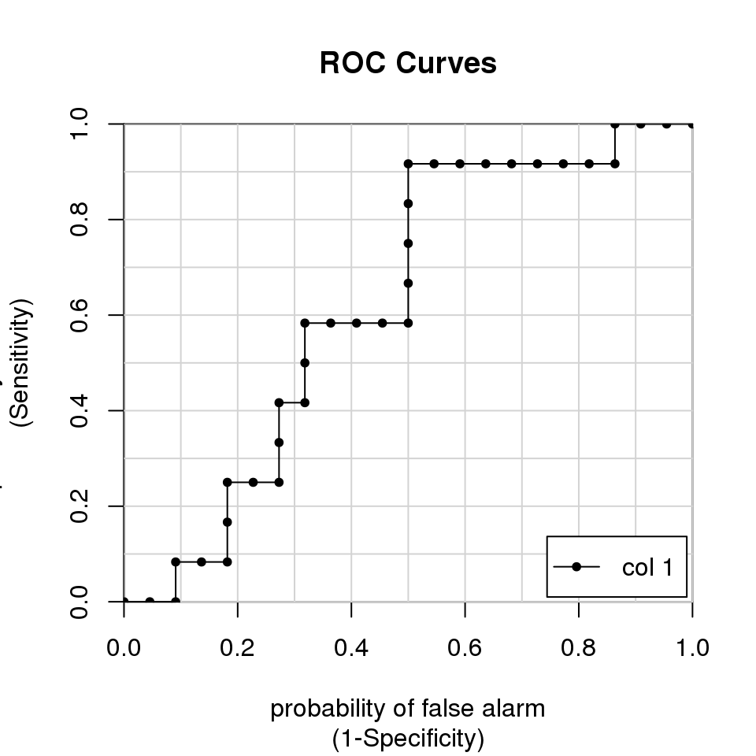

```
                     [,1]
homeless vs. housed 0.625
```

```r
> library(caTools)
> colAUC(PM, testData4$homeless, plotROC = TRUE)
```

An AUC of 0.5 is no better than random guessing, an AUC of 1.0 is a perfectly predictive model, and an AUC of 0.0 is perfectly anti-predictive (which rarely happens). One can use the `trainControl()` function in `caret` to use AUC (instead of acccuracy), to tune the parameters of your models. The `twoClassSummary()` convenience function allows one to do this easily.

When using `twoClassSummary()`, be sure to always include the argument `classProbs = TRUE` or your model will throw an error! (You cannot calculate AUC with just class predictions. You need to have class probabilities as well.)

```r
> # Create trainControl object: myControl
> myControl <- trainControl(
+   method = "cv",
+   number = 10,
+   summaryFunction = twoClassSummary,
+   classProbs = TRUE, # IMPORTANT!
+   verboseIter = FALSE
+ )
> #
> # Train glm with custom trainControl: model
> model <- train(homeless ~ ., data = trainData4, method = "glmStepAIC",
+                trControl = myControl)
```

[output not shown]

[output cut: 6051 more lines]

```
- pss_fr    1   79.783  93.783
- female    1   82.121  96.121
- i1        1   86.744 100.744

Step:  AIC=91.38
.outcome ~ dayslink + female + g1byes + i1 + pss_fr + sexrisk

           Df Deviance     AIC
<none>          77.385  91.385
- sexrisk   1   79.519  91.519
- dayslink  1   80.603  92.603
- pss_fr    1   80.916  92.916
- g1byes    1   81.468  93.468
- female    1   83.654  95.654
- i1        1   88.139 100.139
```

```r
> # Print model to console
> model
```

```
Generalized Linear Model with Stepwise Feature Selection

83 samples
29 predictors
 2 classes: 'homeless', 'housed'

No pre-processing
Resampling: Cross-Validated (10 fold)
Summary of sample sizes: 75, 74, 74, 75, 75, 74, ...
Resampling results:

  ROC        Sens  Spec
  0.5688889  0.66  0.3666667
```

```r
> summary(model)
```

```
Call:
NULL

Deviance Residuals:
    Min       1Q   Median       3Q      Max
-2.1433  -0.6923  -0.3944   0.7927   1.9780

Coefficients:
             Estimate Std. Error z value Pr(>|z|)
(Intercept) -0.898093   0.951086  -0.944   0.3450
dayslink     0.003429   0.001979   1.733   0.0831 .
female       1.801138   0.764603   2.356   0.0185 *
g1byes      -1.338143   0.710160  -1.884   0.0595 .
i1          -0.057817   0.023137  -2.499   0.0125 *
pss_fr       0.159495   0.087981   1.813   0.0699 .
sexrisk     -0.161055   0.112725  -1.429   0.1531
---
Signif. codes:  0 '***' 0.001 '**' 0.01 '*' 0.05 '.' 0.1 ' ' 1

(Dispersion parameter for binomial family taken to be 1)

    Null deviance: 108.605  on 82  degrees of freedom
Residual deviance:  77.385  on 76  degrees of freedom
AIC: 91.385

Number of Fisher Scoring iterations: 6
```

## 1.3 GLMNET

- `alpha = 0` -> ridge
- `alpha = 1` -> lasso

```r
> # Create custom trainControl: myControl
> myControl <- trainControl(
+   method = "cv", number = 10,
+   summaryFunction = twoClassSummary,
+   classProbs = TRUE, # IMPORTANT!
+   verboseIter = TRUE
+ )
> # Train glmnet with custom trainControl and tuning: model
> model <- train(
+   homeless ~ ., HELP,
+   tuneGrid = expand.grid(alpha  = 0:1, lambda = seq(0.0001, 4, length = 20)),
+   method = "glmnet",
+   trControl = myControl
+ )
> # Print model to console
> model
```

```
glmnet

117 samples
 29 predictor
  2 classes: 'homeless', 'housed'

No pre-processing
Resampling: Cross-Validated (10 fold)
Summary of sample sizes: 106, 105, 106, 106, 105, 105, ...
Resampling results across tuning parameters:

  alpha  lambda     ROC        Sens       Spec
  0      0.0001000  0.5840179  0.7017857  0.390
  0      0.2106211  0.6191964  0.7696429  0.240
  0      0.4211421  0.6520536  0.8357143  0.195
```

[output cut: 40 more lines]

```r
> # Print maximum ROC statistic
> max(model[["results"]][["ROC"]])
```

```
[1] 0.6733929
```

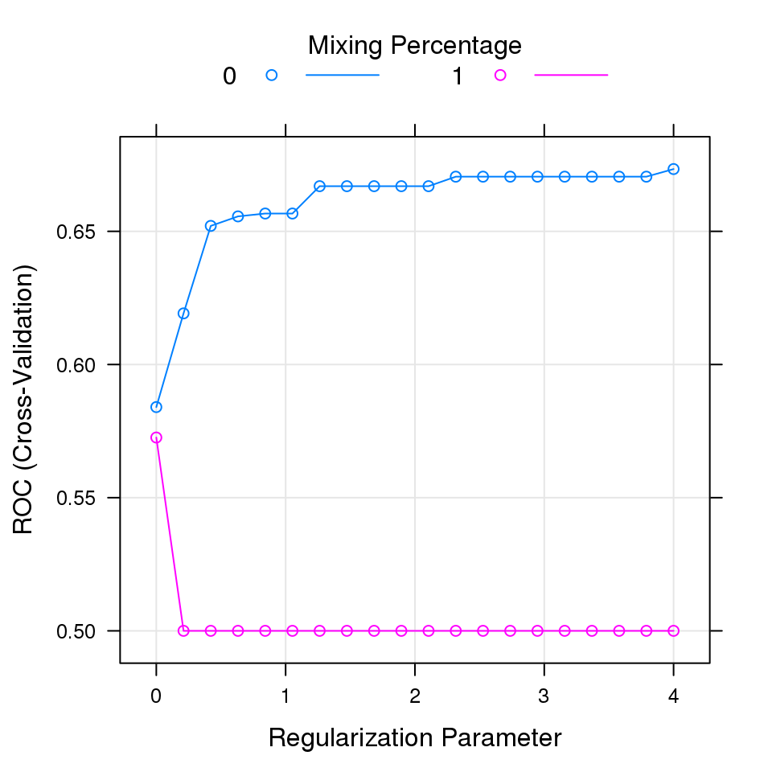

```r
> plot(model)
```

### 1.3.1 Imputation

- Median (`medianImpute`)
- knn (`knnImpute`)
- bagged tree model (`bagImpute`)

```r
> # Create custom trainControl: myControl
> myControl <- trainControl(
+   method = "cv", number = 10,
+   summaryFunction = twoClassSummary,
+   classProbs = TRUE, # IMPORTANT!
+   verboseIter = TRUE
+ )
>
> # Train glmnet with custom trainControl and tuning: model
>
> model <- train(
+   homeless ~ ., data = HELPrct,
+   tuneGrid = expand.grid(alpha  = 0:1, lambda = seq(0.0001, 100, length = 20)),
+   method = "glmnet",
+   metric = "ROC",
+   trControl = myControl,
+   preProcess = c("knnImpute"),
+   na.action = na.omit
+ )
> # Print model to console
> model
```

```
glmnet

453 samples
 28 predictor
  2 classes: 'homeless', 'housed'

Pre-processing: nearest neighbor imputation (31), centered (31),
 scaled (31)
Resampling: Cross-Validated (10 fold)
Summary of sample sizes: 106, 105, 105, 105, 105, 106, ...
Resampling results across tuning parameters:

  alpha  lambda      ROC        Sens       Spec
  0        0.000100  0.5910714  0.7017857  0.285
  0        5.263253  0.6947321  1.0000000  0.000
```

[output cut: 41 more lines]

```r
> # Print maximum ROC statistic
> max(model[["results"]][["ROC"]])
```

```
[1] 0.6985714
```

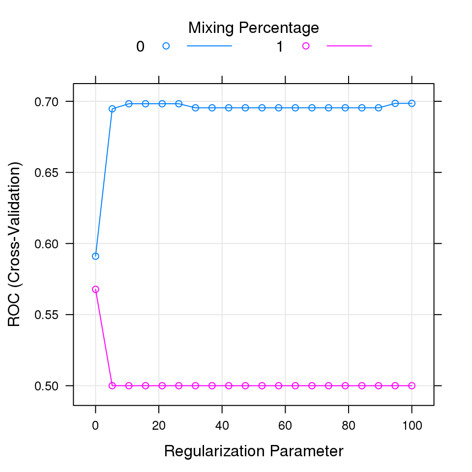

```r
> plot(model)
```

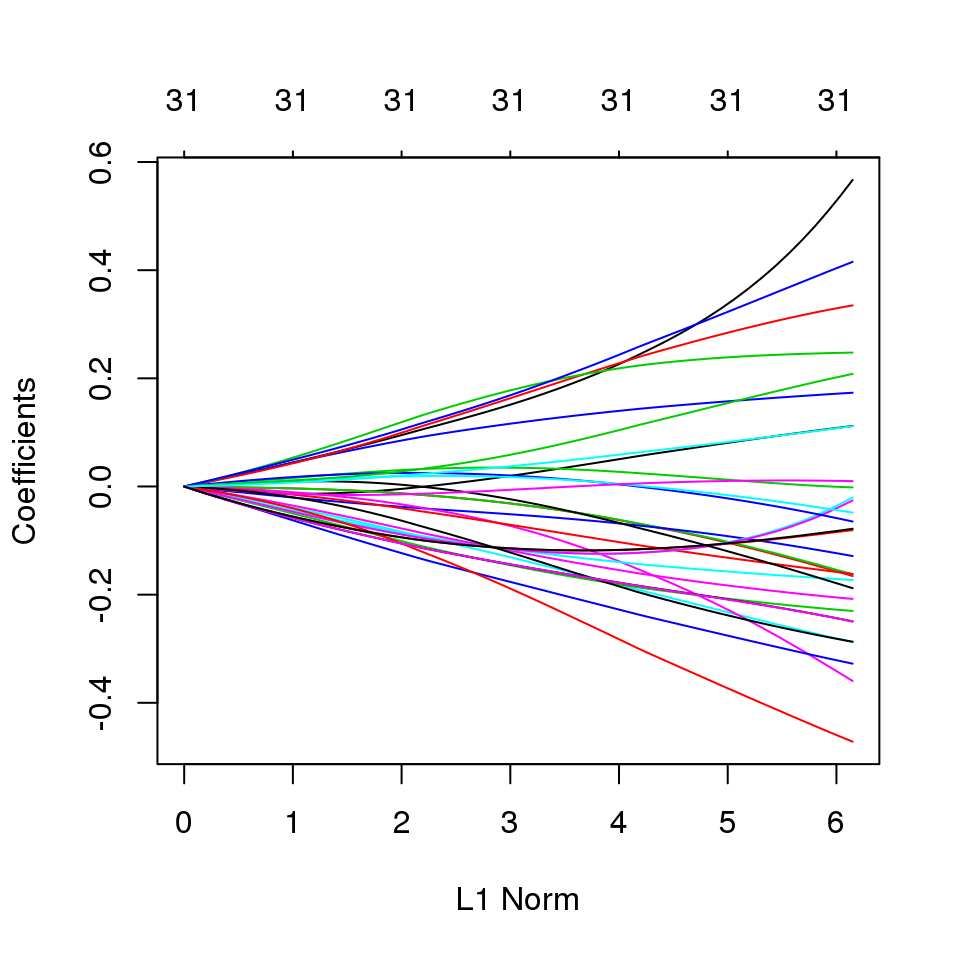

```r
> plot(model$finalModel)
```

```r
> # getting coefficients
> coef(model$finalModel, model$bestTune$lambda)
```

```
32 x 1 sparse Matrix of class "dgCMatrix"
                             1
(Intercept)      -5.798284e-01
age              -4.917266e-04
anysubstatus     -8.023398e-05
anysubyes        -8.021784e-05
cesd             -3.967276e-04
d1               -7.668611e-04
daysanysub       -1.002871e-04
dayslink          7.808609e-04
drugrisk         -1.874202e-04
e2b              -9.760592e-04
female            8.382956e-04
sexmale          -8.381248e-04
g1byes           -6.054235e-04
i1               -1.331805e-03
i2               -1.301941e-03
id                2.568618e-04
indtot           -1.195053e-03
linkstatus       -9.029789e-04
linkyes          -9.027953e-04
mcs               2.214712e-04
pcs               7.483092e-04
pss_fr            8.796997e-04
racegrphispanic   4.108269e-04
racegrpother      2.454697e-04
racegrpwhite     -3.754286e-04
satreatyes       -2.160434e-04
sexrisk          -6.120321e-04
substancecocaine  2.393099e-04
substanceheroin   9.378296e-04
treatyes          9.258989e-05
avg_drinks       -1.331088e-03
max_drinks       -1.301211e-03
```

## 1.4 Working with ISLR data

### 1.4.1 First Ridge

```r
> library(ISLR)
> library(caret)
> Hitters <- na.omit(Hitters)
> summary(Hitters)
```

```
     AtBat            Hits           HmRun            Runs
 Min.   : 19.0   Min.   :  1.0   Min.   : 0.00   Min.   :  0.00
 1st Qu.:282.5   1st Qu.: 71.5   1st Qu.: 5.00   1st Qu.: 33.50
 Median :413.0   Median :103.0   Median : 9.00   Median : 52.00
 Mean   :403.6   Mean   :107.8   Mean   :11.62   Mean   : 54.75
 3rd Qu.:526.0   3rd Qu.:141.5   3rd Qu.:18.00   3rd Qu.: 73.00
 Max.   :687.0   Max.   :238.0   Max.   :40.00   Max.   :130.00
      RBI             Walks            Years            CAtBat
 Min.   :  0.00   Min.   :  0.00   Min.   : 1.000   Min.   :   19.0
 1st Qu.: 30.00   1st Qu.: 23.00   1st Qu.: 4.000   1st Qu.:  842.5
 Median : 47.00   Median : 37.00   Median : 6.000   Median : 1931.0
 Mean   : 51.49   Mean   : 41.11   Mean   : 7.312   Mean   : 2657.5
 3rd Qu.: 71.00   3rd Qu.: 57.00   3rd Qu.:10.000   3rd Qu.: 3890.5
 Max.   :121.00   Max.   :105.00   Max.   :24.000   Max.   :14053.0
     CHits            CHmRun           CRuns             CRBI
 Min.   :   4.0   Min.   :  0.00   Min.   :   2.0   Min.   :   3.0
 1st Qu.: 212.0   1st Qu.: 15.00   1st Qu.: 105.5   1st Qu.:  95.0
 Median : 516.0   Median : 40.00   Median : 250.0   Median : 230.0
 Mean   : 722.2   Mean   : 69.24   Mean   : 361.2   Mean   : 330.4
 3rd Qu.:1054.0   3rd Qu.: 92.50   3rd Qu.: 497.5   3rd Qu.: 424.5
 Max.   :4256.0   Max.   :548.00   Max.   :2165.0   Max.   :1659.0
     CWalks       League  Division    PutOuts          Assists
 Min.   :   1.0   A:139   E:129    Min.   :   0.0   Min.   :  0.0
 1st Qu.:  71.0   N:124   W:134    1st Qu.: 113.5   1st Qu.:  8.0
 Median : 174.0                    Median : 224.0   Median : 45.0
 Mean   : 260.3                    Mean   : 290.7   Mean   :118.8
 3rd Qu.: 328.5                    3rd Qu.: 322.5   3rd Qu.:192.0
 Max.   :1566.0                    Max.   :1377.0   Max.   :492.0
     Errors           Salary       NewLeague
 Min.   : 0.000   Min.   :  67.5   A:141
 1st Qu.: 3.000   1st Qu.: 190.0   N:122
 Median : 7.000   Median : 425.0
 Mean   : 8.593   Mean   : 535.9
 3rd Qu.:13.000   3rd Qu.: 750.0
 Max.   :32.000   Max.   :2460.0
```

```r
> dim(Hitters)
```

```
[1] 263  20
```

```r
> #
> set.seed(1)
> myControl <- trainControl(
+   method = "cv",
+   number = 5
+ )
> hit.model <- train(
+   Salary ~ ., data = Hitters,
+   tuneGrid = expand.grid(alpha = 0, lambda = 10^seq(10, -2, length = 100)),
+   method = "glmnet",
+   trControl = myControl
+ )
> hit.model
```

```
glmnet

263 samples
 19 predictor

No pre-processing
Resampling: Cross-Validated (5 fold)
Summary of sample sizes: 211, 210, 212, 209, 210
Resampling results across tuning parameters:

  lambda        RMSE      Rsquared   MAE
  1.000000e-02  329.6763  0.4644643  231.5502
  1.321941e-02  329.6763  0.4644643  231.5502
  1.747528e-02  329.6763  0.4644643  231.5502
  2.310130e-02  329.6763  0.4644643  231.5502
  3.053856e-02  329.6763  0.4644643  231.5502
  4.037017e-02  329.6763  0.4644643  231.5502
  5.336699e-02  329.6763  0.4644643  231.5502
  7.054802e-02  329.6763  0.4644643  231.5502
  9.326033e-02  329.6763  0.4644643  231.5502
  1.232847e-01  329.6763  0.4644643  231.5502
  1.629751e-01  329.6763  0.4644643  231.5502
  2.154435e-01  329.6763  0.4644643  231.5502
  2.848036e-01  329.6763  0.4644643  231.5502
  3.764936e-01  329.6763  0.4644643  231.5502
  4.977024e-01  329.6763  0.4644643  231.5502
  6.579332e-01  329.6763  0.4644643  231.5502
  8.697490e-01  329.6763  0.4644643  231.5502
  1.149757e+00  329.6763  0.4644643  231.5502
  1.519911e+00  329.6763  0.4644643  231.5502
  2.009233e+00  329.6763  0.4644643  231.5502
  2.656088e+00  329.6763  0.4644643  231.5502
  3.511192e+00  329.6763  0.4644643  231.5502
  4.641589e+00  329.6763  0.4644643  231.5502
  6.135907e+00  329.6763  0.4644643  231.5502
  8.111308e+00  329.6763  0.4644643  231.5502
  1.072267e+01  329.6763  0.4644643  231.5502
  1.417474e+01  329.6763  0.4644643  231.5502
  1.873817e+01  329.6763  0.4644643  231.5502
  2.477076e+01  329.5996  0.4647449  231.4432
```

[output cut: 60 more lines]

```
  6.135907e+08  447.7659        NaN  344.0038
  8.111308e+08  447.7659        NaN  344.0038
  1.072267e+09  447.7659        NaN  344.0038
  1.417474e+09  447.7659        NaN  344.0038
  1.873817e+09  447.7659        NaN  344.0038
  2.477076e+09  447.7659        NaN  344.0038
  3.274549e+09  447.7659        NaN  344.0038
  4.328761e+09  447.7659        NaN  344.0038
  5.722368e+09  447.7659        NaN  344.0038
  7.564633e+09  447.7659        NaN  344.0038
  1.000000e+10  447.7659        NaN  344.0038

Tuning parameter 'alpha' was held constant at a value of 0
RMSE was used to select the optimal model using the smallest value.
The final values used for the model were alpha = 0 and lambda = 24.77076.
```

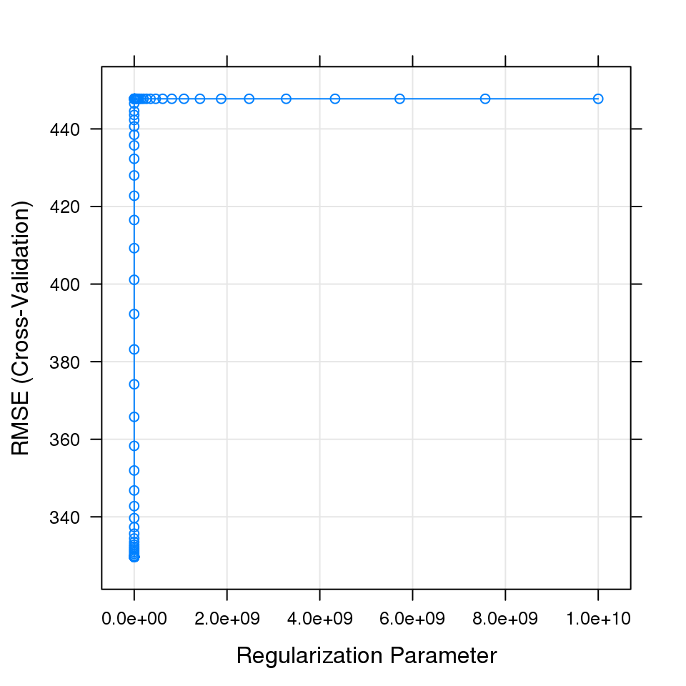

```r
> plot(hit.model)
```

```r
> coef(hit.model$finalModel, hit.model$bestTune$lambda)
```

```
20 x 1 sparse Matrix of class "dgCMatrix"
                        1
(Intercept)  8.112693e+01
AtBat       -6.815959e-01
Hits         2.772312e+00
HmRun       -1.365680e+00
Runs         1.014826e+00
RBI          7.130224e-01
Walks        3.378558e+00
Years       -9.066800e+00
CAtBat      -1.199478e-03
CHits        1.361029e-01
CHmRun       6.979958e-01
CRuns        2.958896e-01
CRBI         2.570711e-01
CWalks      -2.789666e-01
LeagueN      5.321272e+01
DivisionW   -1.228345e+02
PutOuts      2.638876e-01
Assists      1.698796e-01
Errors      -3.685645e+00
NewLeagueN  -1.810510e+01
```

```r
> hit.model$bestTune$lambda
```

```
[1] 24.77076
```

```r
> coef(hit.model$finalModel, s = 11498)
```

```
20 x 1 sparse Matrix of class "dgCMatrix"
                        1
(Intercept) 407.205936774
AtBat         0.037003083
Hits          0.138357552
HmRun         0.525195508
Runs          0.230978290
RBI           0.240114775
Walks         0.289971555
Years         1.108832399
CAtBat        0.003135215
CHits         0.011666684
CHmRun        0.087642789
CRuns         0.023406258
CRBI          0.024165723
CWalks        0.025042117
LeagueN       0.086629234
DivisionW    -6.225431332
PutOuts       0.016506596
Assists       0.002616335
Errors       -0.020564158
NewLeagueN    0.302922899
```

```r
> coef(hit.model$finalModel, s = 0)
```

```
20 x 1 sparse Matrix of class "dgCMatrix"
                        1
(Intercept)  8.112693e+01
AtBat       -6.815959e-01
Hits         2.772312e+00
HmRun       -1.365680e+00
Runs         1.014826e+00
RBI          7.130224e-01
Walks        3.378558e+00
Years       -9.066800e+00
CAtBat      -1.199478e-03
CHits        1.361029e-01
CHmRun       6.979958e-01
CRuns        2.958896e-01
CRBI         2.570711e-01
CWalks      -2.789666e-01
LeagueN      5.321272e+01
DivisionW   -1.228345e+02
PutOuts      2.638876e-01
Assists      1.698796e-01
Errors      -3.685645e+00
NewLeagueN  -1.810510e+01
```

### 1.4.2 Next Lasso

```r
> set.seed(14)
> library(ISLR)
> library(caret)
> Hitters <- na.omit(Hitters)
> summary(Hitters)
```

```
     AtBat            Hits           HmRun            Runs
 Min.   : 19.0   Min.   :  1.0   Min.   : 0.00   Min.   :  0.00
 1st Qu.:282.5   1st Qu.: 71.5   1st Qu.: 5.00   1st Qu.: 33.50
 Median :413.0   Median :103.0   Median : 9.00   Median : 52.00
 Mean   :403.6   Mean   :107.8   Mean   :11.62   Mean   : 54.75
 3rd Qu.:526.0   3rd Qu.:141.5   3rd Qu.:18.00   3rd Qu.: 73.00
 Max.   :687.0   Max.   :238.0   Max.   :40.00   Max.   :130.00
      RBI             Walks            Years            CAtBat
 Min.   :  0.00   Min.   :  0.00   Min.   : 1.000   Min.   :   19.0
 1st Qu.: 30.00   1st Qu.: 23.00   1st Qu.: 4.000   1st Qu.:  842.5
 Median : 47.00   Median : 37.00   Median : 6.000   Median : 1931.0
 Mean   : 51.49   Mean   : 41.11   Mean   : 7.312   Mean   : 2657.5
 3rd Qu.: 71.00   3rd Qu.: 57.00   3rd Qu.:10.000   3rd Qu.: 3890.5
 Max.   :121.00   Max.   :105.00   Max.   :24.000   Max.   :14053.0
     CHits            CHmRun           CRuns             CRBI
 Min.   :   4.0   Min.   :  0.00   Min.   :   2.0   Min.   :   3.0
 1st Qu.: 212.0   1st Qu.: 15.00   1st Qu.: 105.5   1st Qu.:  95.0
 Median : 516.0   Median : 40.00   Median : 250.0   Median : 230.0
 Mean   : 722.2   Mean   : 69.24   Mean   : 361.2   Mean   : 330.4
 3rd Qu.:1054.0   3rd Qu.: 92.50   3rd Qu.: 497.5   3rd Qu.: 424.5
 Max.   :4256.0   Max.   :548.00   Max.   :2165.0   Max.   :1659.0
     CWalks       League  Division    PutOuts          Assists
 Min.   :   1.0   A:139   E:129    Min.   :   0.0   Min.   :  0.0
 1st Qu.:  71.0   N:124   W:134    1st Qu.: 113.5   1st Qu.:  8.0
 Median : 174.0                    Median : 224.0   Median : 45.0
 Mean   : 260.3                    Mean   : 290.7   Mean   :118.8
 3rd Qu.: 328.5                    3rd Qu.: 322.5   3rd Qu.:192.0
 Max.   :1566.0                    Max.   :1377.0   Max.   :492.0
     Errors           Salary       NewLeague
 Min.   : 0.000   Min.   :  67.5   A:141
 1st Qu.: 3.000   1st Qu.: 190.0   N:122
 Median : 7.000   Median : 425.0
 Mean   : 8.593   Mean   : 535.9
 3rd Qu.:13.000   3rd Qu.: 750.0
 Max.   :32.000   Max.   :2460.0
```

```r
> #
> myControl <- trainControl(
+   method = "cv",
+   number = 10
+ )
> hit.model <- train(
+   Salary ~ ., data = Hitters,
+   tuneGrid = expand.grid(alpha = 1, lambda = 10^seq(10, -2, length = 100)),
+   method = "glmnet",
+   trControl = myControl
+ )
> hit.model
```

```
glmnet

263 samples
 19 predictor

No pre-processing
Resampling: Cross-Validated (10 fold)
Summary of sample sizes: 237, 236, 236, 238, 237, 236, ...
Resampling results across tuning parameters:

  lambda        RMSE      Rsquared   MAE
  1.000000e-02  334.5099  0.4830079  240.8482
  1.321941e-02  334.5099  0.4830079  240.8482
  1.747528e-02  334.5099  0.4830079  240.8482
  2.310130e-02  334.5099  0.4830079  240.8482
  3.053856e-02  334.5099  0.4830079  240.8482
  4.037017e-02  334.5099  0.4830079  240.8482
  5.336699e-02  334.5099  0.4830079  240.8482
  7.054802e-02  334.5099  0.4830079  240.8482
  9.326033e-02  334.5100  0.4830072  240.8487
  1.232847e-01  334.5115  0.4829508  240.8343
  1.629751e-01  334.3879  0.4831899  240.7272
  2.154435e-01  334.1270  0.4837221  240.4760
  2.848036e-01  333.9303  0.4842774  240.2570
  3.764936e-01  333.6938  0.4850666  239.9973
  4.977024e-01  333.4366  0.4858907  239.6513
  6.579332e-01  333.2771  0.4866316  239.3565
  8.697490e-01  333.3062  0.4867625  239.1694
  1.149757e+00  333.4537  0.4865981  239.0857
  1.519911e+00  332.8014  0.4879136  238.1150
  2.009233e+00  331.8852  0.4900351  236.5570
  2.656088e+00  331.4881  0.4910937  235.1311
  3.511192e+00  332.0841  0.4894962  234.2894
  4.641589e+00  333.5571  0.4854215  233.7098
  6.135907e+00  335.7066  0.4794635  234.0057
  8.111308e+00  336.1565  0.4781025  233.7759
  1.072267e+01  333.6062  0.4865273  231.5254
  1.417474e+01  333.5142  0.4879453  231.6919
  1.873817e+01  333.7610  0.4892415  232.1512
  2.477076e+01  334.7643  0.4895356  233.0765
```

[output cut: 60 more lines]

```
  6.135907e+08  445.0224        NaN  343.4260
  8.111308e+08  445.0224        NaN  343.4260
  1.072267e+09  445.0224        NaN  343.4260
  1.417474e+09  445.0224        NaN  343.4260
  1.873817e+09  445.0224        NaN  343.4260
  2.477076e+09  445.0224        NaN  343.4260
  3.274549e+09  445.0224        NaN  343.4260
  4.328761e+09  445.0224        NaN  343.4260
  5.722368e+09  445.0224        NaN  343.4260
  7.564633e+09  445.0224        NaN  343.4260
  1.000000e+10  445.0224        NaN  343.4260

Tuning parameter 'alpha' was held constant at a value of 1
RMSE was used to select the optimal model using the smallest value.
The final values used for the model were alpha = 1 and lambda = 2.656088.
```

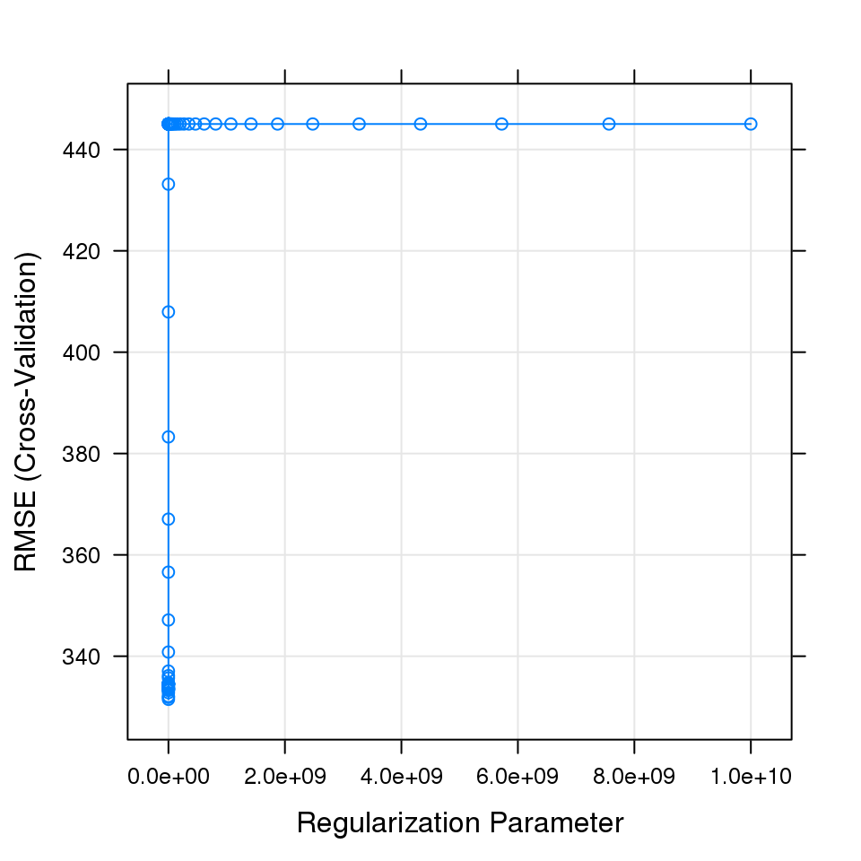

```r
> plot(hit.model)
```

```r
> coef(hit.model$finalModel, hit.model$bestTune$lambda)
```

```
20 x 1 sparse Matrix of class "dgCMatrix"
                       1
(Intercept)  124.1880134
AtBat         -1.5523977
Hits           5.6720579
HmRun          .
Runs           .
RBI            .
Walks          4.7387154
Years         -9.6248231
CAtBat         .
CHits          .
CHmRun         0.5128709
CRuns          0.6611566
CRBI           0.3925662
CWalks        -0.5312257
LeagueN       32.0958342
DivisionW   -119.3027940
PutOuts        0.2725419
Assists        0.1741567
Errors        -2.0667117
NewLeagueN     .
```